# Kaggle: StackSample: 10% of Stack Overflow Q&A

Bryant Mondragon

November 23, 2018

### Introduction to data

This is a dataset that is organized as three tables:

1. Questions contains the title, body, creation date, closed date (if applicable), score, and owner ID for all non-deleted Stack Overflow questions whose Id is a multiple of 10.
2. Answers contains the body, creation date, score, and owner ID for each of the answers to these questions. The ParentId column links back to the Questions table.
3. Tags contains the tags on each of these questions

In this file, I will try to explore the 10% Stackoverflow Dataset. It contains thousands of questions and answer sessions in Stackoverflow.

```r
library(readr)
Answers <- read_csv("C:\\Users\\Bryant\\Documents\\VSCode\\R\\project\\stacksample\\Answers.csv")
head(Answers)
```

```
## # A tibble: 6 x 6
##      Id OwnerUserId CreationDate        ParentId Score Body
##   <dbl>       <dbl> <dttm>                 <dbl> <dbl> <chr>
## 1    92          61 2008-08-01 14:45:37       90    13 "<p><a href=\"http~
## 2   124          26 2008-08-01 16:09:47       80    12 "<p>I wound up usi~
## 3   199          50 2008-08-01 19:36:46      180     1 "<p>I've read some~
## 4   269          91 2008-08-01 23:49:57      260     4 "<p>Yes, I thought~
## 5   307          49 2008-08-02 01:49:46      260    28 "<p><a href=\"http~
## 6   332          59 2008-08-02 03:00:24      330    19 "<p>I would be a b~
```

```r
Questions <- read_csv("C:\\Users\\Bryant\\Documents\\VSCode\\R\\project\\stacksample\\Questions.csv")
head(Questions)
```

```
## # A tibble: 6 x 7
##      Id OwnerUserId CreationDate        ClosedDate          Score Title
##   <dbl>       <dbl> <dttm>              <dttm>              <dbl> <chr>
## 1    80          26 2008-08-01 13:57:07 NA                     26 SQLS~
## 2    90          58 2008-08-01 14:41:24 2012-12-26 03:45:49   144 Good~
## 3   120          83 2008-08-01 15:50:08 NA                     21 ASP.~
## 4   180     2089740 2008-08-01 18:42:19 NA                     53 Func~
## 5   260          91 2008-08-01 23:22:08 NA                     49 Addi~
## 6   330          63 2008-08-02 02:51:36 NA                     29 Shou~
## # ... with 1 more variable: Body <chr>
```

```r
Tags <- read_csv("C:\\Users\\Bryant\\Documents\\VSCode\\R\\project\\stacksample\\Tags.csv")
head(Tags)
```

```
## # A tibble: 6 x 2
##      Id Tag
##   <dbl> <chr>
## 1    80 flex
## 2    80 actionscript-3
## 3    80 air
## 4    90 svn
## 5    90 tortoisesvn
## 6    90 branch
```

### Summaries and Tables of Questions and Answers portion

The data set of StackOverflow that shows up in our workspace is a data frame but it is very large so it will not display properly so I will be showing just the beginning of the dataset. Each row represents a different question and each column representing a variable to which the question is broken down into. Some examples are ceation date, title of the question and the body of the question.

This allows us to view the names of the variables.

```r
names(Answers)
```

```
## [1] "Id"           "OwnerUserId"  "CreationDate" "ParentId"
## [5] "Score"        "Body"
```

```r
names(Questions)
```

```
## [1] "Id"           "OwnerUserId"  "CreationDate" "ClosedDate"
## [5] "Score"        "Title"        "Body"
```

```r
names(Tags)
```

```
## [1] "Id"  "Tag"
```

Here we can see roughly how great the answers that people gave were. People who are rated below 0 would be considered “bad” answers while those above are “correct/good” answers

```r
summary(Answers$Score)
```

```
##     Min.  1st Qu.   Median     Mean  3rd Qu.     Max.
##  -42.000    0.000    1.000    2.481    2.000 5718.000
```

```r
table(Answers$Score > 0 )
```

```
##
##   FALSE    TRUE
##  812193 1202323
```

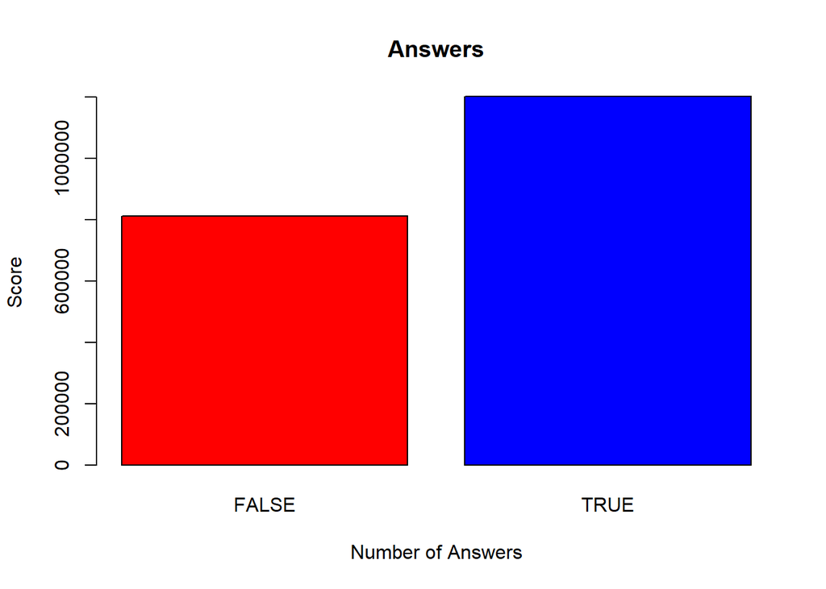

```r
barplot(table(Answers$Score > 0), main="Answers",
  xlab="Number of Answers", ylab="Score", col = c("#ff0000","#0000ff"))
```

```r
min(Questions$CreationDate)
```

```
## [1] "2008-08-01 13:57:07 UTC"
```

```r
Questions[Questions$CreationDate <= "2008-08-01 13:57:07",c('Title','Body')]
```

```
## # A tibble: 3 x 2
##   Title                            Body
##   <chr>                            <chr>
## 1 SQLStatement.execute() - multip~ "<p>I've written a database generation~
## 2 Good branching and merging tuto~ "<p>Are there any really good tutorial~
## 3 ASP.NET Site Maps                "<p>Has anyone got experience creating~
```

Since Stack Overflow did not actually release to the public until September 15, 2008 it is safe to say that they kept record of all their previous questions and answers if they got one.

```r
min(Answers$Id)
```

```
## [1] 92
```

```r
firstAnswer <- Answers[which(Answers$Id=='92'),]
firstAnswer
```

```
## # A tibble: 1 x 6
##      Id OwnerUserId CreationDate        ParentId Score Body
##   <dbl>       <dbl> <dttm>                 <dbl> <dbl> <chr>
## 1    92          61 2008-08-01 14:45:37       90    13 "<p><a href=\"http~
```

Here is the last question that they took before creating the dataset, can you solve it?

```r
max(Questions$Id)
```

```
## [1] 40143380
```

```r
lastQuestion <- Questions[which(Questions$Id=='40143380'),]
lastQuestion
```

```
## # A tibble: 1 x 7
##       Id OwnerUserId CreationDate        ClosedDate          Score Title
##    <dbl>       <dbl> <dttm>              <dttm>              <dbl> <chr>
## 1 4.01e7     6823982 2016-10-19 23:57:31 NA                      0 npm ~
## # ... with 1 more variable: Body <chr>
```

As you can, see it wasn’t a very good question.

```r
sum(is.na(Questions$ClosedDate))
```

```
## [1] 1208257
```

That is a little over 95% of these questions! More things to note is that the answers given can refer to multiple in one question.

### Analyzing ‘Tag’

Here we can see that out of about 3.750 Million tags only a small fraction of them were unique, according to the table below.

```r
df <- Tags[!duplicated(Tags$Tag),]
df
```

```
## # A tibble: 37,036 x 2
##       Id Tag
##    <dbl> <chr>
##  1    80 flex
##  2    80 actionscript-3
##  3    80 air
##  4    90 svn
##  5    90 tortoisesvn
##  6    90 branch
##  7    90 branching-and-merging
##  8   120 sql
##  9   120 asp.net
## 10   120 sitemap
## # ... with 37,026 more rows
```

```r
tb <- table(Tags$Tag)
head(tb)
```

```
##
##            .a          .app     .aspxauth .bash-profile   .class-file
##            13            14             6            46            19
##          .doc
##            16
```

Since this dataset is so large, RStudio cannot actually output all the different but, if we were to put into a table we would be able to Map out how many times a certain tag appears. Ideally we would plot this data in addition to its date to figure out how popular something became over time.

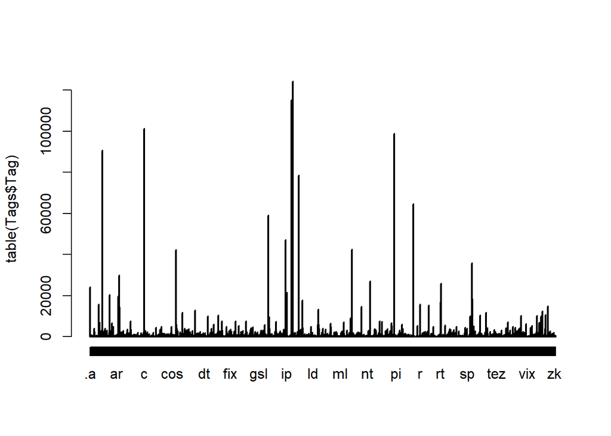

```r
plot(table(Tags$Tag))
```